# Monday 10-26

*Textbook Coverage: 8.1 and 8.2*

Let's do some exercises together on the repl:

```python
def Sumodds(mylist):
    oddnumbers=[]
    for i in mylist:
        if i%2 != 0:
            oddnumbers.append(i)

    return sum(oddnumbers)
```

```python
Sumodds([1,2,3])
```

```
4
```

```python
def sumOdds(data):
  total = 0
  for number in data:
	    if number%2 == 1:
	      total += number
  return total
```

```python
sumOdds(    [1,2,3, 4, 5, 0]    )
```

```
9
```

```python
def sumOdds(data):
  total = 0
  for number in data:
	    if number%2 == 1:
	      total += number
  return total
```

```python
def countNames(words):
    count = 0
    for word in words:
        if word[0].isupper() and word[1:len(word)].islower():
                             #everything after the 0 element
            count = count +1
    return count

print(countNames(['Fili', 'Oin', 'Thorin', 'and', 'Bilbo', 'are', 'characters', 'in', 'a', 'book', 'by', 'Tolkien']))
```

```
5
```

```python
myString = "this is my example String"
```

```python
myString[:9]
```

```
'this is m'
```

```python
def countNames(words):
  total = 0
  for i in words:
	  if(ord(i[0]) <= 90 and ord(i[0]) >= 65):
	    total += 1
    return total
```

```python
for i in range(65,91):
    print(chr(i))
```

```
A
B
C
D
E
F
G
H
I
J
K
L
M
N
O
P
Q
R
S
T
U
V
W
X
Y
Z
```

```python
if 'string'.capitalize() == 'string'
```

```
  File "<ipython-input-67-246c8e35e673>", line 1
    if 'string'.capitalize() == 'string'
                                        ^
SyntaxError: invalid syntax
```

```python
myString = "string"
```

```python
if myString.capitalize() == myString:
    count +=1
```

[output not shown]

# Friday 10-30

*Texbtook Coverage: 8.3*

We've seen several "data structures" in this class. A data structure is a formalized method of representing a collection of information.

Examples:

- Lists. Indexed by number starting at zero. Mutable! All lists are objects, and inherit member functions from the list class.
- Strings, ie collections of characters. Not mutable! Indexed by number staring at zero. Also an object, all strings inherit class methods.

Today, we'll meet "dictionaries".

Let's make an examle dictionary:

```python
yearInSchool = { "alex":"junior", "beth":"sophomore", "chris":"senior"  }
```

```python
print(yearInSchool)
```

```
{'alex': 'junior', 'beth': 'sophomore', 'chris': 'senior'}
```

```python
exampleList = [1, 3, 6, 1, "word"]
```

```python
exampleList
```

```
[1, 3, 6, 1, 'word']
```

Dictionaries are made up of pairs of "keys" and "values". Keys come first, values come second.

Major difference between dictionaries and lists: the items of a dictionary are NOT ORDERED!!!

Instead, they're indexed by the keys (which could be any data type!)

To access elements by key, use [] (just like lists)

```python
yearInSchool["alex"]
```

```
'junior'
```

In python, easy to see all the keys and values with class functions:

```python
yearInSchool.keys()
```

```
dict_keys(['alex', 'beth', 'chris'])
```

```python
yearInSchool.values()
```

```
dict_values(['junior', 'sophomore', 'senior'])
```

One thing that dictionaries have in common with lists: they're "mutable"! Ie, we can change the elements after creating the dictionary.

```python
yearInSchool["alex"] = "sophomore"
```

```python
yearInSchool
```

```
{'alex': 'sophomore', 'beth': 'sophomore', 'chris': 'senior'}
```

```python
yearInSchool["deb"] = "freshman"
```

```python
yearInSchool
```

```
{'alex': 'sophomore',
 'beth': 'sophomore',
 'chris': 'senior',
 'deb': 'freshman'}
```

Cool application for dictionries (8.3): frequencies.

Let's use a dictionary to keep track of the frequencies of letters in a given string.

```python
exampleString = "this is my example string that I'm using to test the frequency count functionality of dictionaries"
```

Game plan: for each character in the string, check to see if it's already in our dictionary. If so, increment the frequency. Otherwise, add it with frequency 1.

```python
dict = {}    #empty dictionary to store the pairs

for char in exampleString:
    if char in dict.keys():
        dict[char] += 1
    else:
        dict[char] = 1
```

```python
dict
```

```
{'t': 12,
 'h': 3,
 'i': 9,
 's': 6,
 ' ': 15,
 'm': 3,
 'y': 3,
 'e': 7,
 'x': 1,
 'a': 4,
 'p': 1,
 'l': 2,
 'r': 3,
 'n': 7,
 'g': 2,
 'I': 1,
 "'": 1,
 'u': 4,
 'o': 5,
 'f': 3,
 'q': 1,
 'c': 4,
 'd': 1}
```

Q: Can we visualize this?

A: Yes! use a bar plot

```
<BarContainer object of 23 artists>
```

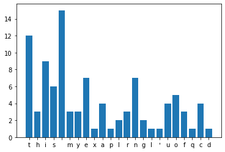

```python
import matplotlib.pyplot as pyplot

pyplot.bar( dict.keys(), dict.values()    )    #first enter x vals (categories), then enter yvals (frequencies)
```